# Machine Learning Assignment

Raul Caceres

10 March 2015

# Executive Summary

6 participants used accelerometers to measure activity through a wearable device. These participants were asked to perform barbell lifts correctly and incorrectly in 5 different ways.

The goal of this paper is to predict the manner in which each of the participants did the exercise.

```r
# We first need to load a few libraries that will be required during the analysis
library(caret)
```

```r
library(corrplot)
library(kernlab)
library(knitr)
library(randomForest)
```

The data for this paper was kindly made available by http://groupware.les.inf.puc-rio.br/har

We initially need to load and clean the training data that will be used for the analysis and which we will use to develop the model that will be later on used with the test data

```r
training <- read.csv("pml-training.csv", na.strings= c("NA",""," ")) #read file
trainingNA <- apply(training, 2, function(x) {sum(is.na(x))})
trainingClean <- training[,which(trainingNA == 0)]
trainingClean <- trainingClean[8:length(trainingClean)]
```

We will now split the cleaned data into training and validation

```r
inTrain <- createDataPartition(y = trainingClean$classe, p = 0.7, list = FALSE)
training <- trainingClean[inTrain, ]
crossval <- trainingClean[-inTrain, ]
```

A correlation plot was created to identify correlations across the different vairables.

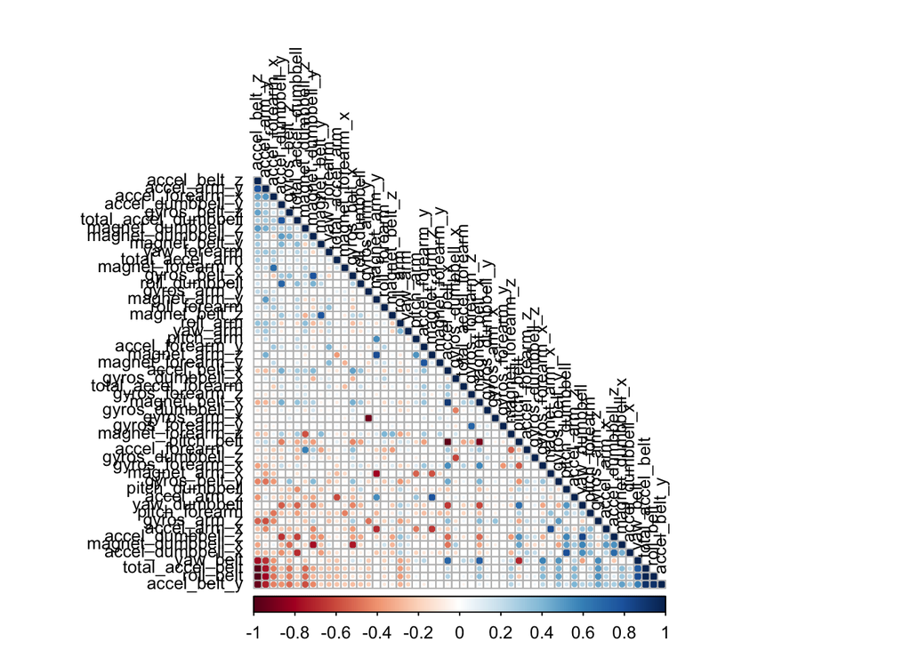

```r
correlMatrix <- cor(training[, -length(training)])
corrplot(correlMatrix, order = "FPC", method = "circle", type = "lower", tl.cex = 0.8,  tl.col = rgb(0, 0, 0))
```

And a random forest model was used to use the different variables.

```r
rfModel <- randomForest(classe ~ ., data = training)
rfModel
```

```
##
## Call:
##  randomForest(formula = classe ~ ., data = training)
##                Type of random forest: classification
##                      Number of trees: 500
## No. of variables tried at each split: 7
##
##         OOB estimate of  error rate: 0.49%
## Confusion matrix:
##      A    B    C    D    E class.error
## A 3900    5    1    0    0 0.001536098
## B   11 2641    6    0    0 0.006395786
## C    0   15 2381    0    0 0.006260434
## D    0    0   21 2230    1 0.009769094
## E    0    0    2    5 2518 0.002772277
```

The model found is then used wiwth the cross validation set.

```r
predictCrossVal <- predict(rfModel, crossval)
confusionMatrix(crossval$classe, predictCrossVal)
```

```
## Confusion Matrix and Statistics
##
##           Reference
## Prediction    A    B    C    D    E
##          A 1673    1    0    0    0
##          B    6 1132    1    0    0
##          C    0    7 1019    0    0
##          D    0    0    7  956    1
##          E    0    0    0    2 1080
##
## Overall Statistics
##
##                Accuracy : 0.9958
##                  95% CI : (0.9937, 0.9972)
##     No Information Rate : 0.2853
##     P-Value [Acc > NIR] : < 2.2e-16
##
##                   Kappa : 0.9946
##  Mcnemar's Test P-Value : NA
##
## Statistics by Class:
##
##                      Class: A Class: B Class: C Class: D Class: E
## Sensitivity            0.9964   0.9930   0.9922   0.9979   0.9991
## Specificity            0.9998   0.9985   0.9986   0.9984   0.9996
## Pos Pred Value         0.9994   0.9939   0.9932   0.9917   0.9982
## Neg Pred Value         0.9986   0.9983   0.9984   0.9996   0.9998
## Prevalence             0.2853   0.1937   0.1745   0.1628   0.1837
## Detection Rate         0.2843   0.1924   0.1732   0.1624   0.1835
## Detection Prevalence   0.2845   0.1935   0.1743   0.1638   0.1839
## Balanced Accuracy      0.9981   0.9958   0.9954   0.9981   0.9993
```

This is then finally applied to the test set.

```r
#Clean the data
test <- read.csv("pml-testing.csv", na.strings= c("NA",""," "))
testNA <- apply(test, 2, function(x) {sum(is.na(x))})
testClean <- test[,which(testNA == 0)]
testClean <- testClean[8:length(testClean)]
```

And we then apply the model to the test set

```r
predictTest <- predict(rfModel, testClean)
predictTest
```

```
##  1  2  3  4  5  6  7  8  9 10 11 12 13 14 15 16 17 18 19 20
##  B  A  B  A  A  E  D  B  A  A  B  C  B  A  E  E  A  B  B  B
## Levels: A B C D E
```